# Homework 1

Katherine Idziorek

April 4, 2017

### **Overview of the Swiss Fertility and Socioeconomic Indicators Data (1888)**

##### This dataset provides standardized fertility measures and socioeconomic indicators for the 47 French-speaking provinces of Switzerland circa 1888. These variables describe a time of *demographic transition* in Switzerland, when the country’s fertility was beginning to decline from a higher level commonly associated with developing countries. All variables except `Fertility` are provided in units of proportion of the population (%).

### **Study Variables**

##### The study’s indicator variables include:

- `Fertility` *common standard fertility measure (indexed)*
- `Agriculture` *% males involved in agriculture as an occupation*
- `Examination` *% draftees receiving highers mark on army examination*
- `Education` *% education beyond primary school for draftees*
- `Catholic` *% Catholic (as opposed to Protestant)*
- `Infant.Mortality` *% live births who live less than one year*

##### A pairwise comparison of the variables illustrates joint relationships for each combination of categories:

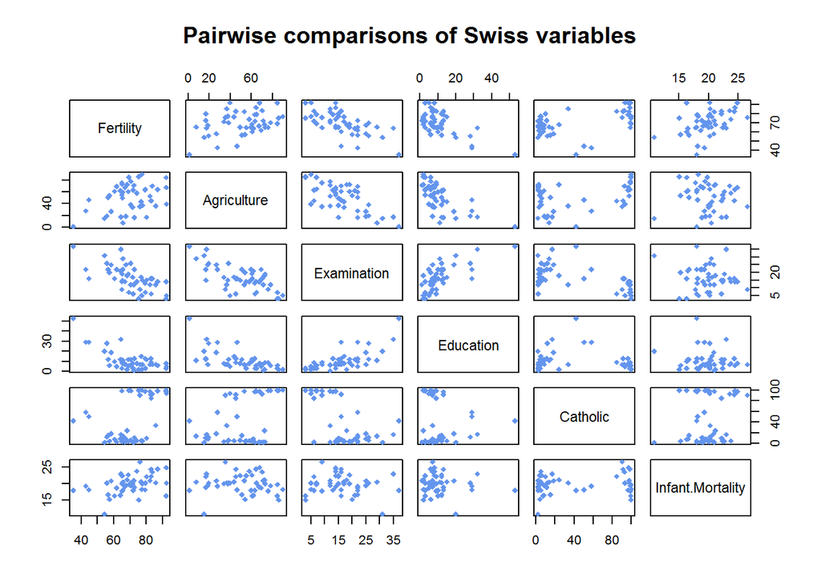

##### We can also look at summary statistics for the individual variables:

**Statistical Summary of Individual Variables**

| Fertility | Agriculture | Examination | Education | Catholic | Infant.Mortality |
| --- | --- | --- | --- | --- | --- |
| Min. :35.00 | Min. : 1.20 | Min. : 3.00 | Min. : 1.00 | Min. : 2.150 | Min. :10.80 |
| 1st Qu.:64.70 | 1st Qu.:35.90 | 1st Qu.:12.00 | 1st Qu.: 6.00 | 1st Qu.: 5.195 | 1st Qu.:18.15 |
| Median :70.40 | Median :54.10 | Median :16.00 | Median : 8.00 | Median : 15.140 | Median :20.00 |
| Mean :70.14 | Mean :50.66 | Mean :16.49 | Mean :10.98 | Mean : 41.144 | Mean :19.94 |
| 3rd Qu.:78.45 | 3rd Qu.:67.65 | 3rd Qu.:22.00 | 3rd Qu.:12.00 | 3rd Qu.: 93.125 | 3rd Qu.:21.70 |
| Max. :92.50 | Max. :89.70 | Max. :37.00 | Max. :53.00 | Max. :100.000 | Max. :26.60 |

### **Education and Fertility**

##### Looking specifically at the relationship between `Education` and `Fertility`, we can see that `Fertility` generally decreases as `Education` increases (see graph below). As we observed in the summary table above, the minimum and maximum values of `Fertility` are 35 and 92.5, respectively; the minimum and maximum values of `Education` are 1% and 53%, respectively.

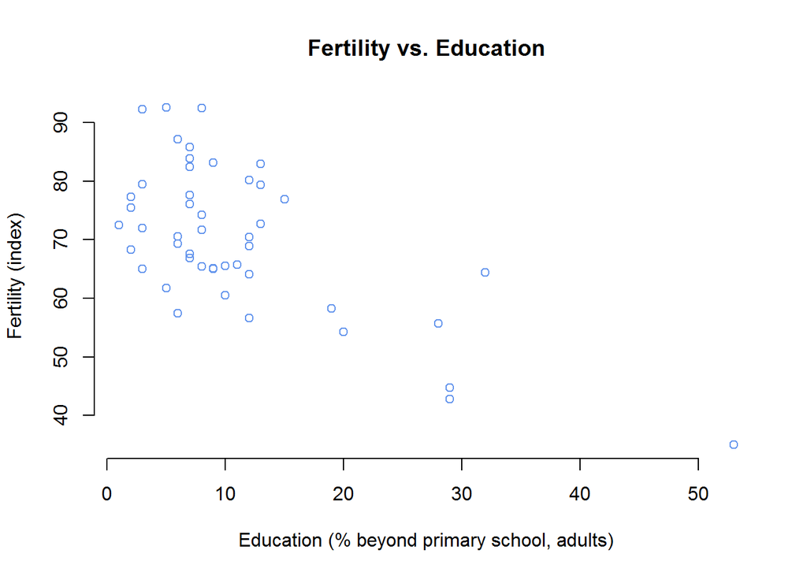